# Week1: Linear Models

# Objective

This homework sheet will help reviewing the basic concepts associated with linear regression models. Please review the lectures, suggested readings, and additional resources **before** getting started on the HW

**Some questions in this assignment will require you to conduct independent research beyond the material covered in the recorded content.**

**Questions**

This homework is divided into two main parts. First, a conceptual component will review the basic concepts related to linear models. The second part of the homework is mostly intended to be a brief introduction to fitting and analyzing linear models in Python. Several of these questions are modified from James et al. (2021).

Marks Distribution

| Question | Marks |
| --- | --- |
| 1 | 1 |
| 2a | 0.25 |
| 2b | 0.25 |
| 2c | 0.25 |
| 2d | 0.25 |
| 3a | 0.25 |
| 3b | 0.25 |
| 3c | 0.25 |
| 3d | 0.25 |
| 4a.i | 0.25 |
| 4a.ii | 0.25 |
| 4a.iii | 0.25 |
| 4a.iv | 0.50 |
| 4a.v | 0.25 |
| 4a.vi | 0.50 |
| 4b | 0.50 |
| 4c | 0.50 |
| 5a | 0.25 |
| 5b | 0.25 |
| 5c.i | 0.25 |
| 5c.ii | 0.25 |
| 5c.iii | 0.25 |
| 5d | 0.25 |
| 5e | 0.25 |
| 5f | 0.25 |
| 6a | 0.25 |
| 6b | 0.25 |
| 6c | 0.25 |
| 6d | 0.25 |
| 6e | 0.25 |
| 6f | 0.25 |
| 6g | 0.50 |
| 6h | 0.50 |
| 6i | 0.50 |
| 6j | 0.50 |
| 7a | 0.25 |
| 7b | 0.50 |
| 7c | 0.50 |
| 7d | 0.25 |
| 7e | 0.25 |
| 7f | 0.25 |
| 7g | 0.50 |
| 8 | 1 |

The following website has access to the relevant datasets from the recommended textbook: https://book.huihoo.com/introduction-to-statistical-learning/data.html

# Conceptual

## Question 1

Describe the null hypotheses to which the *p*-values given in the table (see below). Explain what conclusions you can draw based on these p-values. Your explanation should be phrased in terms of sales, TV, radio, and newspaper, rather than in terms of the coefficients of the linear model.

|  | Coefficient | Std. error | t-statistics | p-value |
| --- | --- | --- | --- | --- |
| Intercept | 2.939 | 0.3119 | 9.42 | <0.0001 |
| TV | 0.046 | 0.0014 | 32.81 | <0.0001 |
| Radio | 0.189 | 0.0086 | 21.89 | <0.0001 |
| Newspaper | -0.001 | 0.0059 | -0.18 | 0.8599 |

## Answer:

### The null hypothesis ($H_0$) states that for each predictor (TV, Radio, and Newspaper), there is no effect on Sales, meaning that the Beta coefficient ($\beta$) is zero for each predictor.

### TV:

- $H_0$: $\beta_{TV} = 0$
- $H_A$: $\beta_{TV} \neq 0$

### Radio:

- $H_0$: $\beta_{Radio} = 0$
- $H_A$: $\beta_{Radio} \neq 0$

### Newspaper:

- $H_0$: $\beta_{Newspaper} = 0$
- $H_A$: $\beta_{Newspaper} \neq 0$

### Interpretations:

- **TV**: The p-value is smaller than **0.05**, so we **reject** $H_0$ and accept $H_A$.
  - **Conclusion**: There is a statistically significant relationship between **TV ads and Sales**.
- **Radio**: The p-value is smaller than **0.05**, so we **reject** $H_0$ and accept $H_A$.
  - **Conclusion**: There is a statistically significant relationship between **Radio ads and Sales**.
- **Newspaper**: The p-value is **greater than 0.05** (0.8599), so we **fail to reject** $H_0$.
  - **Conclusion**: There is **no evidence** of a statistically significant relationship between **Newspaper ads and Sales**.

## Question 2

Assume that you collected a dataset of 100 observations containing a single predictor and a quantitative response. Then, you decided to fit a

(i) linear regression model to the data, as well as a separate

(ii) cubic regression, i.e. $Y = β_{0} + β_{1}X^{1} + β_{2}X^{2} + β_{3}X^{3} + ϵ$

### a) Suppose that the true relationship between $X$ and $Y$ is linear, i.e. $Y = β_{0} + β_{1}X + ϵ$. Consider the training residual sum of squares (*RSS*) for the linear regression, and also the training *RSS* for the cubic regression. Would we expect one to be lower than the other, would we expect them to be the same, or is there not enough information to tell? Justify your answer

Simple linear regression is highly interpretable but has low flexibility, while cubic regression is more flexible but less interpretable. Since cubic regression can capture more complex patterns in the data, its training RSS will always be lower or equal to that of linear regression. However, this increased flexibility can lead to overfitting, as the model may also capture noise rather than just the true underlying trend.

### b) Answer part (a) using the test *RSS* rather than training *RSS*.

Simple linear regression is highly interpretable but less flexible, while cubic regression is more flexible but harder to interpret. Although the cubic model fits the training data better, its test RSS may be higher than that of the linear model if it overfits the training data. Overfitting causes the cubic model to capture noise rather than the true pattern, making it perform worse on new, unseen data. In contrast, the linear model may generalize better, leading to a lower test RSS when the true relationship is close to linear.

### c) Suppose that the true relationship between $X$ and $Y$ is not linear. However, we don’t know how far it is from linear. Consider the training *RSS* for the linear regression, and also the training *RSS* for the cubic regression. Would we expect one to be lower than the other, would we expect them to be the same, or is there not enough information to tell? Justify your answer.

If the true relationship between X and 𝑌 is not linear, but we are unsure of the degree of non-linearity, we can compare the training RSS for both linear and cubic regression models.

Since cubic regression is more flexible, it can better fit the data, capturing both the true pattern and potential noise. This means that the training RSS for the cubic model will always be lower than or equal to that of the linear model. However, whether this flexibility is beneficial depends on how far the true relationship deviates from linearity. If the relationship is only slightly non-linear, the cubic model may overfit and capture noise rather than meaningful patterns. If the relationship is highly non-linear, the cubic model will fit better than the linear model.

Thus, while we expect the cubic regression to have a lower training RSS, this does not necessarily mean it will perform better on unseen data, as it might overfit.

### d) Answer (c) using test *RSS* rather than training *RSS.*

Since we don’t know how much the true relationship is nonlinear, it’s hard to say which model will have a lower test RSS. If the relationship is only slightly curved, the linear model will likely perform better. But if the relationship is strongly curved, the cubic model will likely have a lower test RSS.

## Question 3

### a) Discuss the implications that uncertainty in $X$ would have on parameter estimates based on linear regression models. Should we care about error in $X$ when fitting OLS regressions?

Uncertainty in X can cause inaccurate parameter estimates, increasing standard errors and reducing prediction accuracy. It is important to consider errors in X rather than ignoring them to build a more reliable and accurate model.

### b) Provide a brief discussion on the concept of regression dilution.

Regression dilution happens when measurement error in X weakens the estimated relationship between X and Y, for example students incorrectly reporting their hours of studies for exams. This causes the slope estimate to be biased, making the effect seem different than it really is. It leads to inaccurate conclusions and weaker predictions. Using more precise measurements or statistical corrections can help reduce this bias.

### c) Are there any linear regression models that account for uncertainty in $X$ and $Y$? Please do some independent research and cite your sources.

When measurement errors are present in either predictor or response variables, traditional OLS regression may not be appropriate. Models like Total Least Squares, Deming Regression, and Weighted Least Squares are designed to account for these uncertainties, leading to more reliable parameter estimates.

**References**

**Errors in variables regression:**  
Wikipedia: https://en.wikipedia.org/wiki/Errors-in-variables_model  
Youtube: https://youtu.be/Pz4ephK-f94?si=xqc0UygHYLuIOKMJ

**Total Least Square:**  
Wikipedia: https://en.wikipedia.org/wiki/Total_least_squares  
Youtube: https://youtu.be/zstTZf5AiWE?si=2XBb4hsVHVcMZfPh

**Deeming Regression**  
Wikipedia: https://en.wikipedia.org/wiki/Deming_regression  
Youtube: https://youtu.be/roVR8H3x2-U?si=IJox0ZptvLvHSSJW

**Weighted Least Square**

Wikipedia: https://en.wikipedia.org/wiki/Weighted_least_squares  
Youtube: https://youtu.be/wCJ8I-MtJdQ?si=Vrubxfgj8II8afVi

### d) Distinguish between least squares and maximum likelihood in the context of linear regression models

In the context of linear regression models, Least Squares and Maximum Likelihood Estimation (MLE) both lead to the same parameter estimates under normally distributed errors, but they use different approaches.

- Least Squares focuses on minimizing the sum of squared differences between observed and predicted values, finding the best-fitting line.
- MLE focuses on maximizing the likelihood of the observed data, estimating parameters that make the given data most probable.

In summary, Least Squares is a geometric approach to fitting a line, while MLE is a statistical approach based on probability maximization.

# Applied

Please note that some of the questions outlined below make suggestions on potential functions to be used in the answers. Feel free to use any other function. These are just a reference.

## Question 4

This question involves the use of simple linear regression on the Auto data set.

### a) Use the " OLS() function " from " Statsmodels " library to perform a simple linear regression with " mpg " as the response and " horsepower" as the predictor. Use the "summary()" function to print the results. Then, answer the questions below:

Reference to Statsmodels library and ols :

https://www.statsmodels.org/dev/generated/statsmodels.regression.linear_model.OLS.html#generated-statsmodels-regression-linear-model-ols--page-root

```python
# Uncomment and install them if needed.

#! pip install statsmodels
#! pip install scipy
#! pip install sklearn

pass
```

```python
#IMPORT LIBRARIES
from pprint import pprint
import numpy as np
import pandas as pd
import matplotlib.pyplot as plt
import seaborn as sns
import statsmodels.api as sm
import statsmodels.formula.api as smf
from sklearn.model_selection import train_test_split
from scipy.optimize import fsolve
```

```python
#READ AUTO.CSV DATASET
df_auto = pd.read_csv('Auto.csv')

pprint(df_auto.head(5))
pprint(df_auto.info())
```

```
    mpg  cylinders  displacement horsepower  weight  acceleration  year  \
0  18.0          8         307.0        130    3504          12.0    70
1  15.0          8         350.0        165    3693          11.5    70
2  18.0          8         318.0        150    3436          11.0    70
3  16.0          8         304.0        150    3433          12.0    70
4  17.0          8         302.0        140    3449          10.5    70

   origin                       name
0       1  chevrolet chevelle malibu
1       1          buick skylark 320
2       1         plymouth satellite
3       1              amc rebel sst
4       1                ford torino
<class 'pandas.core.frame.DataFrame'>
RangeIndex: 397 entries, 0 to 396
Data columns (total 9 columns):
 #   Column        Non-Null Count  Dtype
---  ------        --------------  -----
 0   mpg           397 non-null    float64
 1   cylinders     397 non-null    int64
 2   displacement  397 non-null    float64
 3   horsepower    397 non-null    object
 4   weight        397 non-null    int64
 5   acceleration  397 non-null    float64
 6   year          397 non-null    int64
 7   origin        397 non-null    int64
 8   name          397 non-null    object
dtypes: float64(3), int64(4), object(2)
memory usage: 28.0+ KB
None
```

```python
#PERFORM PRE PROCESSING OF DATA IF REQUIRED ( OBSERVE THE DATASET AND ITS VALUES CAREFULLY)

print(f"\n{df_auto.info()}")
# We need to change the dtatype of horsepower to int which
print(f"\n{df_auto.describe(include='all')}")
# There are no null values
print(f"\n{df_auto.isnull().sum()}")

# We need to change the type of hosepower from object to integer.
print(f"\n{df_auto['horsepower'].unique()}")

# There are some values containing question marks in horsepower, we need to fix them.

# 2. Identify rows where horsepower == '?'
missing_hp_rows = df_auto[df_auto['horsepower'] == '?']
print(f"\nRows with missing horsepower:")
print(missing_hp_rows)

# 3. Replace '?' with NaN
df_auto.loc[df_auto['horsepower'] == '?', 'horsepower'] = np.nan

# 4. Convert horsepower column to float
df_auto['horsepower'] = df_auto['horsepower'].astype('float')

# 5. Fill missing horsepower with the mean HP for that car name
df_auto['horsepower'] = df_auto.groupby('name')['horsepower'].transform(
    lambda x: x.fillna(x.mean())
)

# For the remaining values We might want to fill those remaining NaNs with a global mean.
df_auto['horsepower'] = df_auto['horsepower'].fillna(
    df_auto['horsepower'].mean()
)

# 4. Convert horsepower column to float
df_auto['horsepower'] = df_auto['horsepower'].astype('int64')

print(f"\nAfter handling NAN or ? values:")
print(df_auto.isnull().sum())
```

```
<class 'pandas.core.frame.DataFrame'>
RangeIndex: 397 entries, 0 to 396
Data columns (total 9 columns):
 #   Column        Non-Null Count  Dtype
---  ------        --------------  -----
 0   mpg           397 non-null    float64
 1   cylinders     397 non-null    int64
 2   displacement  397 non-null    float64
 3   horsepower    397 non-null    object
 4   weight        397 non-null    int64
 5   acceleration  397 non-null    float64
 6   year          397 non-null    int64
 7   origin        397 non-null    int64
 8   name          397 non-null    object
dtypes: float64(3), int64(4), object(2)
memory usage: 28.0+ KB

None

               mpg   cylinders  displacement horsepower       weight  \
count   397.000000  397.000000    397.000000        397   397.000000
unique         NaN         NaN           NaN         94          NaN
top            NaN         NaN           NaN        150          NaN
freq           NaN         NaN           NaN         22          NaN
mean     23.515869    5.458438    193.532746        NaN  2970.261965
std       7.825804    1.701577    104.379583        NaN   847.904119
min       9.000000    3.000000     68.000000        NaN  1613.000000
25%      17.500000    4.000000    104.000000        NaN  2223.000000
50%      23.000000    4.000000    146.000000        NaN  2800.000000
75%      29.000000    8.000000    262.000000        NaN  3609.000000
max      46.600000    8.000000    455.000000        NaN  5140.000000

        acceleration        year      origin        name
count     397.000000  397.000000  397.000000         397
unique           NaN         NaN         NaN         304
top              NaN         NaN         NaN  ford pinto
freq             NaN         NaN         NaN           6
mean       15.555668   75.994962    1.574307         NaN
std         2.749995    3.690005    0.802549         NaN
min         8.000000   70.000000    1.000000         NaN
```

[output cut: 36 more lines]

```
330       2  renault lecar deluxe
336       1    ford mustang cobra
354       2           renault 18i

After handling NAN or ? values:
mpg             0
cylinders       0
displacement    0
horsepower      0
weight          0
acceleration    0
year            0
origin          0
name            0
dtype: int64
```

```python
df_auto.describe(include='all').T
```

|  | count | unique | top | freq | mean | std | min | 25% | 50% | 75% | max |
| --- | --- | --- | --- | --- | --- | --- | --- | --- | --- | --- | --- |
| mpg | 397.0 | NaN | NaN | NaN | 23.515869 | 7.825804 | 9.0 | 17.5 | 23.0 | 29.0 | 46.6 |
| cylinders | 397.0 | NaN | NaN | NaN | 5.458438 | 1.701577 | 3.0 | 4.0 | 4.0 | 8.0 | 8.0 |
| displacement | 397.0 | NaN | NaN | NaN | 193.532746 | 104.379583 | 68.0 | 104.0 | 146.0 | 262.0 | 455.0 |
| horsepower | 397.0 | NaN | NaN | NaN | 104.352645 | 38.280617 | 46.0 | 76.0 | 94.0 | 125.0 | 230.0 |
| weight | 397.0 | NaN | NaN | NaN | 2970.261965 | 847.904119 | 1613.0 | 2223.0 | 2800.0 | 3609.0 | 5140.0 |
| acceleration | 397.0 | NaN | NaN | NaN | 15.555668 | 2.749995 | 8.0 | 13.8 | 15.5 | 17.1 | 24.8 |
| year | 397.0 | NaN | NaN | NaN | 75.994962 | 3.690005 | 70.0 | 73.0 | 76.0 | 79.0 | 82.0 |
| origin | 397.0 | NaN | NaN | NaN | 1.574307 | 0.802549 | 1.0 | 1.0 | 1.0 | 2.0 | 3.0 |
| name | 397 | 304 | ford pinto | 6 | NaN | NaN | NaN | NaN | NaN | NaN | NaN |

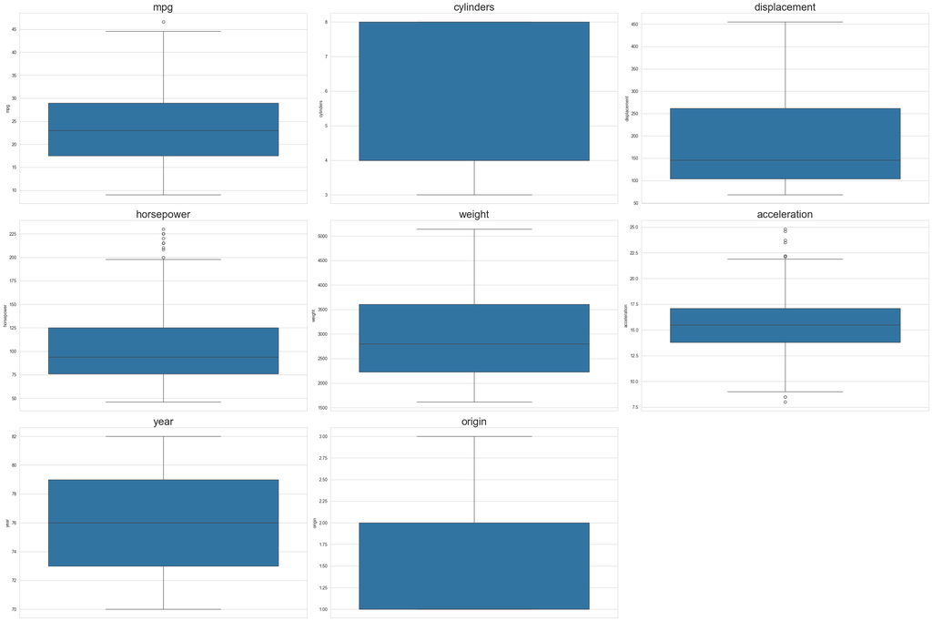

```python
columns = ['mpg', 'cylinders', 'displacement', 'horsepower', 'weight', 'acceleration', 'year', 'origin']

# Set figure size
plt.figure(figsize=(30, 20))

# Create subplots for each column
for i, col in enumerate(columns, 1):
    plt.subplot(3, 3, i)  # Creating a 3x3 grid (adjust if needed)
    sns.boxplot(y=df_auto[col])
    plt.title(col, fontsize=24)

plt.tight_layout()  # Adjust layout for better spacing
plt.show()
```

```python
# Define predictor (X) and response (y)
X = df_auto[['horsepower']]
y = df_auto['mpg']

# We will not use Train Test Split here
#X_train, X_test, y_train, y_test = train_test_split(X, y, test_size=0.3, random_state=4)

# Add constant term for intercept
#X_train = sm.add_constant(X_train)
#X_test = sm.add_constant(X_test)
X = sm.add_constant(X)

# Fit the regression model on training data
#model = sm.OLS(y_train, X_train)
model = sm.OLS(y, X)

results = model.fit()

# Print the summary of regression results
print(results.summary())
```

```
                            OLS Regression Results
==============================================================================
Dep. Variable:                    mpg   R-squared:                       0.594
Model:                            OLS   Adj. R-squared:                  0.593
Method:                 Least Squares   F-statistic:                     577.7
Date:                Thu, 30 Jan 2025   Prob (F-statistic):           2.62e-79
Time:                        22:37:12   Log-Likelihood:                -1200.7
No. Observations:                 397   AIC:                             2405.
Df Residuals:                     395   BIC:                             2413.
Df Model:                           1
Covariance Type:            nonrobust
==============================================================================
                 coef    std err          t      P>|t|      [0.025      0.975]
------------------------------------------------------------------------------
const         39.9563      0.728     54.849      0.000      38.524      41.388
horsepower    -0.1575      0.007    -24.035      0.000      -0.170      -0.145
==============================================================================
Omnibus:                       21.949   Durbin-Watson:                   0.893
Prob(Omnibus):                  0.000   Jarque-Bera (JB):               24.152
Skew:                           0.561   Prob(JB):                     5.69e-06
Kurtosis:                       3.450   Cond. No.                         323.
==============================================================================

Notes:
[1] Standard Errors assume that the covariance matrix of the errors is correctly specified.
```

### i. Is there a relationship between the predictor and the response?

Yes, there is a clear and strong relationship between horsepower and mpg.

1. The p-value (< 0.0001) shows that horsepower significantly affects mpg, meaning this relationship is not due to chance.
2. The R-squared value (0.594) means that 59.4% of the variation in mpg is explained by horsepower. This suggests a fairly strong relationship between the two variables.
3. The negative slope (-0.1575) tells us that as horsepower increases, fuel efficiency (mpg) decreases. Specifically, for every 1-unit increase in horsepower, mpg drops by 0.1575. This confirms that cars with more powerful engines tend to use more fuel per mile.

### Key Takeaway:

Cars with higher horsepower tend to have lower fuel efficiency. This is a strong and statistically significant trend, meaning we can confidently say that horsepower has an important impact on mpg.

### ii. How strong is the relationship between the predictor and the response? Focus on the *RSE*, estimated $R^2$, and *slope.*

1. The R-squared (0.594) shows that horsepower explains 59.4% of the variation in mpg, meaning it is an important factor but not the only one.
2. The slope (-0.1575) confirms a negative relationship, where higher horsepower leads to lower fuel efficiency.

The model is statistically significant and the relationship between horsepower and mpg is moderately strong. Additional predictors like weight, cylinders, acceleration can further improve the model.

### iii. Is the relationship between the predictor and the response positive or negative?

The relationship between predictor(horsepower) and response(mpg) is a negative relationship as the slope of horsepower is negative(-0.1575) implying that when horsepower increases, fuel efficiency (mpg) decreases.

### iv. What is the predicted mpg associated with a **horsepower** of **98**? What are the associated 95% confidence and prediction intervals?

```python
# BEGIN SOLUTION

# Define the horsepower value for prediction
hp_value = pd.DataFrame({'const': [1.0], 'horsepower':[98]}) # 1 is for the intercept term
hp_value = sm.add_constant(hp_value)

# Make prediction with confidence and prediction intervals
mpg_pred = results.get_prediction(hp_value)
mpg_pred_summary = mpg_pred.summary_frame(alpha=0.05) # 95% confidence level

# Print the summary
pprint(mpg_pred_summary)

# END SOLUTION
```

```
        mean   mean_se  mean_ci_lower  mean_ci_upper  obs_ci_lower  \
0  24.516709  0.254044      24.017263      25.016156     14.687204

   obs_ci_upper
0     34.346214
```

Predicted mpg for horsepoer of 98 is $\approx$ 24.51 with confidence interval is (24.01 - 25.01) and prediction interval is (14.68 - 34.34)

### V. **Now, please briefly explain the main use of inverse predictions. List at least two practical examples.**

Inverse prediction also known as calibration is used to find the best input values (X) needed to achieve a desired output (Y). It helps in decision-making and optimization in various fields.

1. Medical Diagnosis: By observing a patient's blood sugar and predicting insulin dosage.
2. Deep Learning: Improving AI Model accuracy by finding the best weights and activation function for better performance.

### vi. use " fsolve function from scipy " (or any function of your preference) to infer horsepower from the same mpg value predicted in (**iv**). Comment on your results.

Link to fsolve from scipy library:

https://docs.scipy.org/doc/scipy/reference/generated/scipy.optimize.fsolve.html

```python
# BEGIN SOLUTION

# Extract coefficients using `.iloc[]`
intercept, slope = results.params.iloc[0], results.params.iloc[1]

# Use a lambda function to define the equation
horsepower_infered = fsolve(lambda hp: intercept + slope * hp - 24.51, x0=100)

print(f"Estimated horsepower for 24.51 mpg: {horsepower_infered[0]:.2f}")

# END SOLUTION
```

```
Estimated horsepower for 24.51 mpg: 98.04
```

### b) Plot the response and the predictor. Use the `lmplot()` function from seaborn to display the least squares regression line.

Link to lmplot() in seaborn:

https://seaborn.pydata.org/archive/0.11/tutorial/regression.html#:~:text=(%22tips%22)-,Functions%20to%20draw%20linear%20regression%20models,much%20of%20their%20core%20functionality.

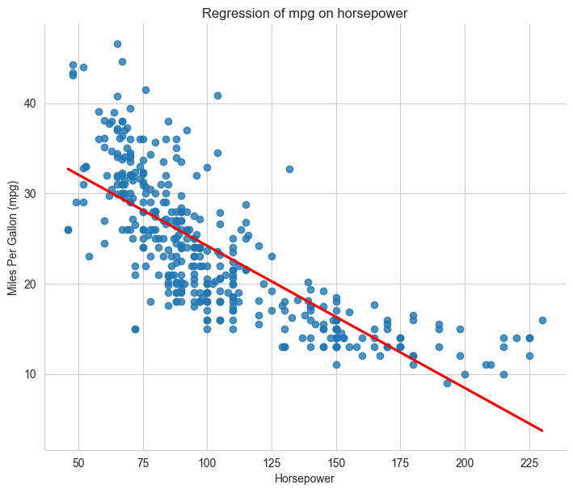

```python
# BEGIN SOLUTION
sns.set_style("whitegrid")
#set the shape for the plot
plt.figure(figsize=(8,5))

# Create a scatter plot with regression line
sns.lmplot(x="horsepower", y="mpg", data=df_auto, height=6, aspect=1.2, ci=None, line_kws={"color": "red"})

# Customize plot
plt.title("Regression of mpg on horsepower")
plt.xlabel("Horsepower")
plt.ylabel("Miles Per Gallon (mpg)")

# Show the plot
plt.show()

# END SOLUTION
```

### c) Use the `plot_fit` function from statsmodels library to produce diagnostic plots of the least squares regression fit. Comment on any problems you see with the fit.

Link to plot_fit:

https://www.statsmodels.org/dev/generated/statsmodels.graphics.regressionplots.plot_fit.html

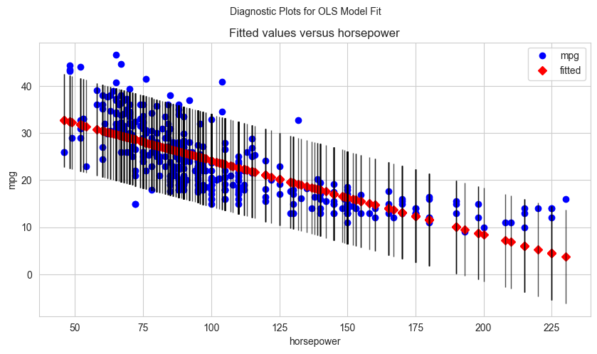

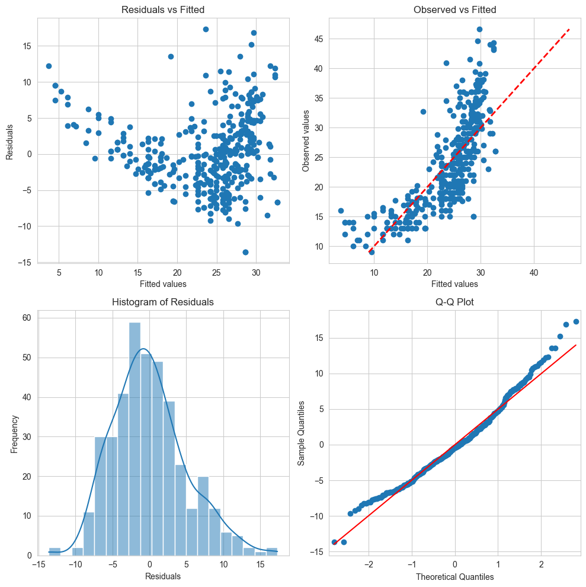

```
                            OLS Regression Results
==============================================================================
Dep. Variable:                    mpg   R-squared:                       0.594
Model:                            OLS   Adj. R-squared:                  0.593
Method:                 Least Squares   F-statistic:                     577.7
Date:                Thu, 30 Jan 2025   Prob (F-statistic):           2.62e-79
Time:                        22:37:14   Log-Likelihood:                -1200.7
No. Observations:                 397   AIC:                             2405.
Df Residuals:                     395   BIC:                             2413.
Df Model:                           1
Covariance Type:            nonrobust
==============================================================================
                 coef    std err          t      P>|t|      [0.025      0.975]
------------------------------------------------------------------------------
const         39.9563      0.728     54.849      0.000      38.524      41.388
horsepower    -0.1575      0.007    -24.035      0.000      -0.170      -0.145
==============================================================================
Omnibus:                       21.949   Durbin-Watson:                   0.893
Prob(Omnibus):                  0.000   Jarque-Bera (JB):               24.152
Skew:                           0.561   Prob(JB):                     5.69e-06
Kurtosis:                       3.450   Cond. No.                         323.
==============================================================================

Notes:
[1] Standard Errors assume that the covariance matrix of the errors is correctly specified.
```

```python
# BEGIN SOLUTION

sns.set_style("whitegrid")
y=df_auto['mpg']
fig, ax = plt.subplots(figsize=(10, 5))

sm.graphics.plot_fit(results, 1, ax=ax)

fig.suptitle('Diagnostic Plots for OLS Model Fit', fontsize=10)
fig.subplots_adjust(top=0.88)

plt.show()

fig, axes = plt.subplots(2, 2, figsize=(10, 10))

# Residuals vs Fitted
axes[0, 0].scatter(results.fittedvalues, results.resid)
axes[0, 0].set_xlabel('Fitted values')
axes[0, 0].set_ylabel('Residuals')
axes[0, 0].set_title('Residuals vs Fitted')

# Observed vs Fitted
axes[0, 1].scatter(results.fittedvalues, y)
axes[0, 1].plot([y.min(), y.max()], [y.min(), y.max()], 'r--', lw=2)
axes[0, 1].set_xlabel('Fitted values')
axes[0, 1].set_ylabel('Observed values')
axes[0, 1].set_title('Observed vs Fitted')

# Histogram of residuals
sns.histplot(results.resid, bins=20, kde=True, ax=axes[1, 0])
axes[1, 0].set_xlabel('Residuals')
axes[1, 0].set_ylabel('Frequency')
axes[1, 0].set_title('Histogram of Residuals')

# Q-Q plot
sm.qqplot(results.resid, line='s', ax=axes[1, 1])
axes[1, 1].set_title('Q-Q Plot')


plt.tight_layout()
plt.show()

# Print summary statistics
print(results.summary())

# END SOLUTION
```

## Question 5

This question involves the use of multiple linear regression on the Auto data set. Read the dataset first:

### a) Produce a scatterplot matrix using pairplot() from seaborn library which includes all of the variables in the data set

Link to pairplot: https://seaborn.pydata.org/generated/seaborn.pairplot.html

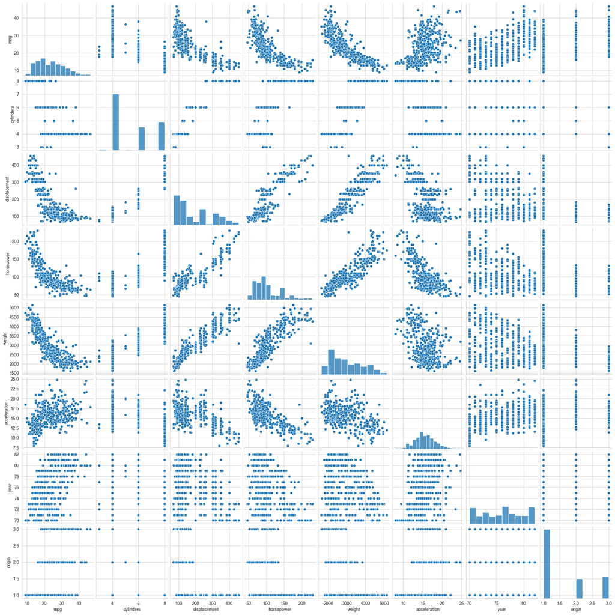

```python
# BEGIN SOLUTION

plt.figure(figsize=(12, 8))
sns.pairplot(df_auto)

# Show the plot
plt.show()

# END SOLUTION
```

### b) Compute the matrix of correlations between the variables using the function `corr()`in pandas on the dataframe also plot the corresponding correlation matrix using `heatmap` function in seaborn

Links:

Corr() : https://pandas.pydata.org/docs/reference/api/pandas.DataFrame.corr.html

Heatmap : https://seaborn.pydata.org/generated/seaborn.heatmap.html

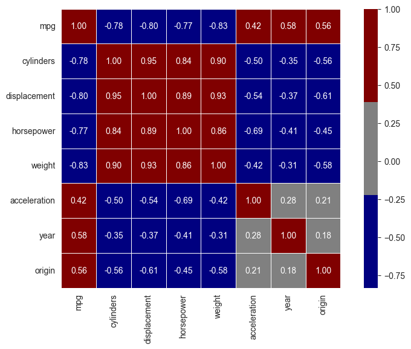

```python
# BEGIN SOLUTION

numerical_cols = df_auto.select_dtypes(include=['number'])
corr = df_auto[numerical_cols.columns].corr()

plt.figure(figsize=(10, 6))
sns.heatmap(
    corr, annot=True, cmap=['navy', 'grey', 'maroon'],
    fmt=".2f", linewidths=0.5, square=True, annot_kws={"size": 10}
)
plt.show()

# END SOLUTION
```

1. Cylinders and Displacement have a strong positive correlation, meaning larger engines tend to have more cylinders.
2. Cylinders and Horsepower are positively correlated, indicating that cars with more cylinders generally produce more power.
3. Cylinders and Weight show a strong positive correlation, meaning larger engines are typically found in heavier cars.
4. Displacement and Horsepower have a strong positive relationship, as bigger engines generally generate more power.
5. Displacement and Weight are positively correlated, meaning vehicles with larger displacement engines tend to weigh more.
6. Horsepower and Weight are also positively correlated, suggesting that higher-powered cars are usually heavier.
7. MPG and Cylinders have a strong negative correlation, indicating that cars with more cylinders tend to have lower fuel efficiency.
8. MPG and Displacement are negatively correlated, meaning larger engine sizes generally reduce fuel economy.
9. MPG and Horsepower show a strong negative correlation, as more powerful cars tend to consume more fuel.
10. MPG and Weight are negatively correlated, meaning heavier vehicles typically have lower fuel efficiency.

### c) Use the `ols()` function from statsmodels library to perform a multiple linear regression with mpg as the response and all other variables except name as the predictors. Use the `summary()` function from statsmodels to print the results. Use the questions below to comment on the output.

Reference to Statsmodels library and ols :

https://www.statsmodels.org/dev/generated/statsmodels.regression.linear_model.OLS.html#generated-statsmodels-regression-linear-model-ols--page-root

Links to summary:

https://www.statsmodels.org/devel/generated/statsmodels.regression.linear_model.OLSResults.summary.html

```python
# BEGIN SOLUTION

# Select predictor variables (exclude 'mpg' and 'name' column)
X = df_auto.drop(columns=['mpg', 'name'])

# Convert categorical variables (if any) to numeric (e.g., one-hot encoding for 'origin' if needed)
if 'origin' in X.columns:
    X = pd.get_dummies(X, columns=['origin'], drop_first=True)  # Convert 'origin' to dummy variables

# Define the response variable
y = df_auto['mpg']

X['origin_2'] = X['origin_2'].astype(int)
X['origin_3'] = X['origin_3'].astype(int)
X = X.apply(pd.to_numeric)  # Ensures all values are numeric

# Add a constant term for the intercept
X = sm.add_constant(X)

# Fit the multiple linear regression model
model = sm.OLS(y, X).fit()

# Print the summary of the regression model
print(model.summary())

# END SOLUTION
```

```
                            OLS Regression Results
==============================================================================
Dep. Variable:                    mpg   R-squared:                       0.825
Model:                            OLS   Adj. R-squared:                  0.821
Method:                 Least Squares   F-statistic:                     228.8
Date:                Thu, 30 Jan 2025   Prob (F-statistic):          8.92e-142
Time:                        22:41:05   Log-Likelihood:                -1033.5
No. Observations:                 397   AIC:                             2085.
Df Residuals:                     388   BIC:                             2121.
Df Model:                           8
Covariance Type:            nonrobust
================================================================================
                   coef    std err          t      P>|t|      [0.025      0.975]
--------------------------------------------------------------------------------
const          -19.4716      4.601     -4.232      0.000     -28.517     -10.426
cylinders       -0.4480      0.320     -1.400      0.162      -1.077       0.181
displacement     0.0236      0.008      3.097      0.002       0.009       0.039
horsepower      -0.0118      0.013     -0.883      0.378      -0.038       0.014
weight          -0.0070      0.001    -10.819      0.000      -0.008      -0.006
acceleration     0.1121      0.097      1.158      0.248      -0.078       0.302
year             0.7894      0.051     15.486      0.000       0.689       0.890
origin_2         2.7516      0.559      4.926      0.000       1.653       3.850
origin_3         2.7969      0.547      5.109      0.000       1.720       3.873
==============================================================================
Omnibus:                       20.815   Durbin-Watson:                   1.273
Prob(Omnibus):                  0.000   Jarque-Bera (JB):               29.661
Skew:                           0.410   Prob(JB):                     3.62e-07
Kurtosis:                       4.059   Cond. No.                     8.59e+04
==============================================================================

Notes:
[1] Standard Errors assume that the covariance matrix of the errors is correctly specified.
[2] The condition number is large, 8.59e+04. This might indicate that there are
strong multicollinearity or other numerical problems.
```

#### i. Is there a significant association between the predictors and the response?

Yes, there is a significant relationship between predictors and response.

- Displacement, Weight, Year, and Origin significantly impact the response.
- Cylinders Horsepower and Acceleration do not significantly contribute.
- The F-statistic is 228.8 which is > 1.
- The probability of F-statistics is < 0.05.
- This confirms that there is a strong relationship between one or many of the predictors variables and response variable.

#### ii. Which predictors appear to have a statistically significant relationship to the response?

The p-values associated with each predictor’s t-statistic indicate that "displacement", "weight", "year", and "origin" have a statistically significant relationship with mpg, while "cylinders", "horsepower", and "acceleration" do not.

#### iii. What does the coefficient for the year variable suggest?

The coefficient of the "year" variable suggests that, on average, for each additional year, mpg increases by 0.7894, assuming all other predictors remain constant.

### d) Use the `plot_fit ()` function from statsmodels to produce diagnostic plots of the linear regression fit. Again, feel free to use any other package or function to create these plots. Comment on any problems you see with the fit. Do the residual plots suggest any unusually large outliers? Does the leverage plot identify any observations with unusually high leverage?

Link to plot_fit:

https://www.statsmodels.org/dev/generated/statsmodels.graphics.regressionplots.plot_fit.html

Link to residual plots:

https://www.statsmodels.org/dev/generated/statsmodels.graphics.regressionplots.plot_leverage_resid2.html

```python
#using plot_fit()
```

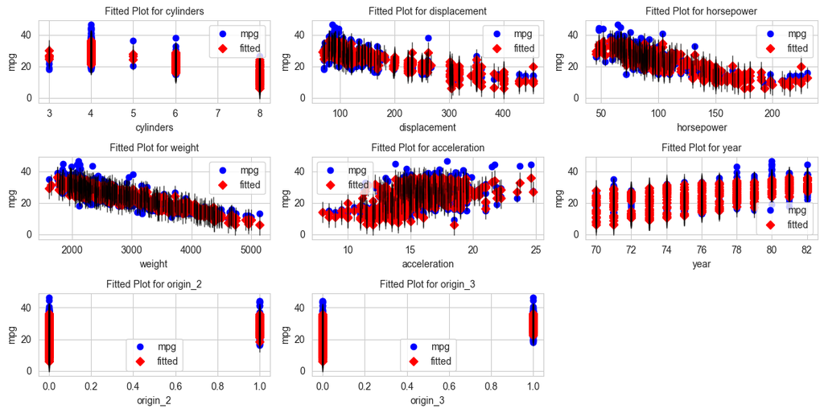

```python
# BEGIN SOLUTION

# Number of predictors (excluding intercept)
num_predictors = len(model.params) - 1

# Ensure grid size adjusts dynamically (Max 3 columns)
rows = (num_predictors // 3) + (num_predictors % 3 > 0)
cols = min(3, num_predictors)

fig, ax = plt.subplots(rows, cols, figsize=(12, 6))

count = 1  # Start from first predictor

for i in range(rows):
    for j in range(cols):
        if count <= num_predictors:
            sm.graphics.plot_fit(model, count, ax=ax[i, j])

            # Set subplot title for better readability
            ax[i, j].set_title(f"Fitted Plot for {model.model.exog_names[count]}", fontsize=10)
            count += 1
        else:
            ax[i, j].axis("off")  # Hide unused subplots

# Adjust layout
fig.tight_layout()
plt.show()

# END SOLUTION
```

```python
#using plot_leverage_resid2
```

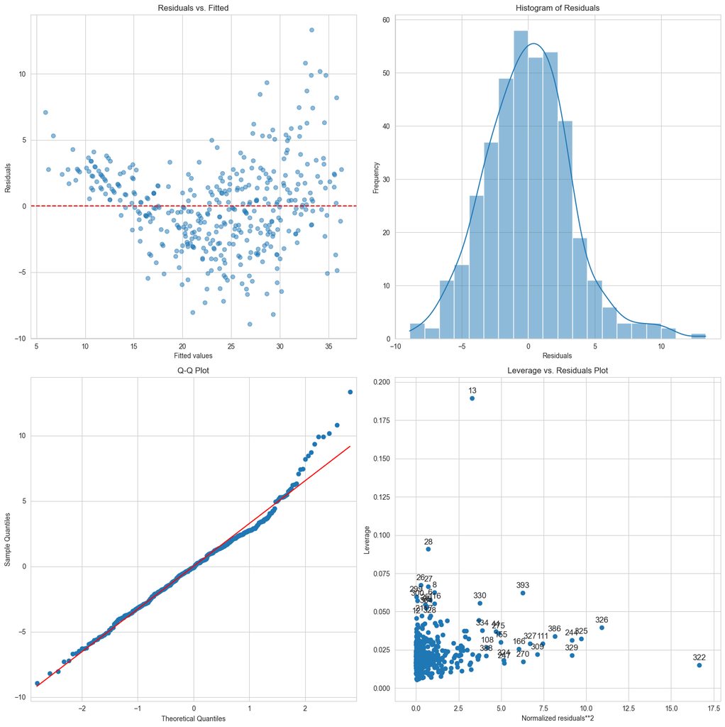

```python
# BEGIN SOLUTION

# Create a 2x2 grid for diagnostic plots
fig, axes = plt.subplots(2, 2, figsize=(15, 15))

# Residuals vs. Fitted
axes[0, 0].scatter(model.fittedvalues, model.resid, alpha=0.5)
axes[0, 0].axhline(y=0, color='red', linestyle='--')  # Horizontal reference line
axes[0, 0].set_xlabel("Fitted values")
axes[0, 0].set_ylabel("Residuals")
axes[0, 0].set_title("Residuals vs. Fitted")

# Histogram of Residuals
sns.histplot(model.resid, bins=20, kde=True, ax=axes[0, 1])
axes[0, 1].set_xlabel("Residuals")
axes[0, 1].set_ylabel("Frequency")
axes[0, 1].set_title("Histogram of Residuals")

# Q-Q Plot (Check for normality)
sm.qqplot(model.resid, line='s', ax=axes[1, 0])
axes[1, 0].set_title("Q-Q Plot")

# Leverage vs. Residuals Plot
sm.graphics.plot_leverage_resid2(model, ax=axes[1, 1])  # High leverage detection
axes[1, 1].set_title("Leverage vs. Residuals Plot")

# Adjust layout
plt.tight_layout()
plt.show()


# END SOLUTION
```

1. Fitted vs actual graphs show the relationship to be non-linear.
2. Leverage vs Normalized residuals squared graph suggests presensce of outliers.

### e) Fit a linear regression model with interaction effects. explore a few different models (~3–4 models). Do any interactions appear to be statistically significant in any of the models you examined?

Use formula.ols to check the interaction between two predictors as used in the below reference link

https://www.statsmodels.org/devel/example_formulas.html

```python
# BEGIN SOLUTION

df_q_5e = df_auto.drop(['name'], axis=1)

model1 = smf.ols(formula='mpg ~ cylinders * displacement + cylinders * weight', data=df_q_5e).fit()

print(model1.summary())

# END SOLUTION
```

```
                            OLS Regression Results
==============================================================================
Dep. Variable:                    mpg   R-squared:                       0.721
Model:                            OLS   Adj. R-squared:                  0.717
Method:                 Least Squares   F-statistic:                     201.7
Date:                Thu, 30 Jan 2025   Prob (F-statistic):          7.12e-106
Time:                        22:46:56   Log-Likelihood:                -1126.5
No. Observations:                 397   AIC:                             2265.
Df Residuals:                     391   BIC:                             2289.
Df Model:                           5
Covariance Type:            nonrobust
==========================================================================================
                             coef    std err          t      P>|t|      [0.025      0.975]
------------------------------------------------------------------------------------------
Intercept                 64.5342      4.534     14.233      0.000      55.620      73.448
cylinders                 -3.8880      0.878     -4.429      0.000      -5.614      -2.162
displacement              -0.0125      0.029     -0.436      0.663      -0.069       0.044
cylinders:displacement    -0.0008      0.004     -0.205      0.838      -0.008       0.007
weight                    -0.0129      0.003     -4.826      0.000      -0.018      -0.008
cylinders:weight           0.0012      0.000      3.023      0.003       0.000       0.002
==============================================================================
Omnibus:                       52.824   Durbin-Watson:                   0.804
Prob(Omnibus):                  0.000   Jarque-Bera (JB):              104.806
Skew:                           0.740   Prob(JB):                     1.74e-23
Kurtosis:                       5.036   Cond. No.                     4.53e+05
==============================================================================

Notes:
[1] Standard Errors assume that the covariance matrix of the errors is correctly specified.
[2] The condition number is large, 4.53e+05. This might indicate that there are
strong multicollinearity or other numerical problems.
```

```python
model2 = smf.ols(formula='mpg ~ cylinders * displacement + displacement * weight', data=df_q_5e).fit()

print(model2.summary())
```

```
                            OLS Regression Results
==============================================================================
Dep. Variable:                    mpg   R-squared:                       0.727
Model:                            OLS   Adj. R-squared:                  0.723
Method:                 Least Squares   F-statistic:                     208.2
Date:                Thu, 30 Jan 2025   Prob (F-statistic):          7.95e-108
Time:                        22:47:08   Log-Likelihood:                -1122.0
No. Observations:                 397   AIC:                             2256.
Df Residuals:                     391   BIC:                             2280.
Df Model:                           5
Covariance Type:            nonrobust
==========================================================================================
                             coef    std err          t      P>|t|      [0.025      0.975]
------------------------------------------------------------------------------------------
Intercept                 52.8518      2.233     23.673      0.000      48.462      57.241
cylinders                  0.7580      0.764      0.992      0.322      -0.745       2.261
displacement              -0.0751      0.017     -4.502      0.000      -0.108      -0.042
cylinders:displacement    -0.0029      0.003     -0.845      0.399      -0.010       0.004
weight                    -0.0099      0.001     -7.505      0.000      -0.013      -0.007
displacement:weight     2.147e-05      5e-06      4.298      0.000    1.16e-05    3.13e-05
==============================================================================
Omnibus:                       55.169   Durbin-Watson:                   0.784
Prob(Omnibus):                  0.000   Jarque-Bera (JB):              103.810
Skew:                           0.789   Prob(JB):                     2.87e-23
Kurtosis:                       4.945   Cond. No.                     9.21e+06
==============================================================================

Notes:
[1] Standard Errors assume that the covariance matrix of the errors is correctly specified.
[2] The condition number is large, 9.21e+06. This might indicate that there are
strong multicollinearity or other numerical problems.
```

```python
model3 = smf.ols(formula='mpg ~ cylinders * displacement + displacement * weight + horsepower * cylinders', data=df_q_5e).fit()

print(model3.summary())
```

```
                            OLS Regression Results
==============================================================================
Dep. Variable:                    mpg   R-squared:                       0.751
Model:                            OLS   Adj. R-squared:                  0.747
Method:                 Least Squares   F-statistic:                     167.7
Date:                Thu, 30 Jan 2025   Prob (F-statistic):          2.65e-113
Time:                        22:47:25   Log-Likelihood:                -1103.6
No. Observations:                 397   AIC:                             2223.
Df Residuals:                     389   BIC:                             2255.
Df Model:                           7
Covariance Type:            nonrobust
==========================================================================================
                             coef    std err          t      P>|t|      [0.025      0.975]
------------------------------------------------------------------------------------------
Intercept                 65.6718      3.136     20.939      0.000      59.505      71.838
cylinders                 -2.4404      0.944     -2.584      0.010      -4.297      -0.584
displacement              -0.0473      0.021     -2.245      0.025      -0.089      -0.006
cylinders:displacement    -0.0007      0.004     -0.184      0.854      -0.008       0.007
weight                    -0.0062      0.001     -4.386      0.000      -0.009      -0.003
displacement:weight     1.135e-05   5.16e-06      2.199      0.028     1.2e-06    2.15e-05
horsepower                -0.2282      0.050     -4.561      0.000      -0.327      -0.130
horsepower:cylinders       0.0257      0.008      3.304      0.001       0.010       0.041
==============================================================================
Omnibus:                       44.614   Durbin-Watson:                   0.911
Prob(Omnibus):                  0.000   Jarque-Bera (JB):               81.428
Skew:                           0.664   Prob(JB):                     2.08e-18
Kurtosis:                       4.777   Cond. No.                     1.36e+07
==============================================================================

Notes:
[1] Standard Errors assume that the covariance matrix of the errors is correctly specified.
[2] The condition number is large, 1.36e+07. This might indicate that there are
strong multicollinearity or other numerical problems.
```

```python
model4 = smf.ols(formula='mpg ~ cylinders * displacement + displacement * weight + horsepower * weight', data=df_q_5e).fit()

print(model4.summary())
```

```
                            OLS Regression Results
==============================================================================
Dep. Variable:                    mpg   R-squared:                       0.747
Model:                            OLS   Adj. R-squared:                  0.742
Method:                 Least Squares   F-statistic:                     163.8
Date:                Thu, 30 Jan 2025   Prob (F-statistic):          7.90e-112
Time:                        22:47:42   Log-Likelihood:                -1107.0
No. Observations:                 397   AIC:                             2230.
Df Residuals:                     389   BIC:                             2262.
Df Model:                           7
Covariance Type:            nonrobust
==========================================================================================
                             coef    std err          t      P>|t|      [0.025      0.975]
------------------------------------------------------------------------------------------
Intercept                 63.2161      3.177     19.897      0.000      56.970      69.463
cylinders                 -1.0385      0.809     -1.284      0.200      -2.629       0.552
displacement              -0.0585      0.023     -2.512      0.012      -0.104      -0.013
cylinders:displacement     0.0059      0.004      1.606      0.109      -0.001       0.013
weight                    -0.0083      0.001     -6.160      0.000      -0.011      -0.006
displacement:weight     3.528e-06   8.41e-06      0.420      0.675    -1.3e-05    2.01e-05
horsepower                -0.1738      0.054     -3.195      0.002      -0.281      -0.067
horsepower:weight       3.122e-05   1.57e-05      1.992      0.047    4.08e-07     6.2e-05
==============================================================================
Omnibus:                       41.897   Durbin-Watson:                   0.892
Prob(Omnibus):                  0.000   Jarque-Bera (JB):               73.078
Skew:                           0.645   Prob(JB):                     1.35e-16
Kurtosis:                       4.659   Cond. No.                     1.50e+07
==============================================================================

Notes:
[1] Standard Errors assume that the covariance matrix of the errors is correctly specified.
[2] The condition number is large, 1.5e+07. This might indicate that there are
strong multicollinearity or other numerical problems.
```

1. Multiple interaction models were tested using different combinations of predictors.
2. Model 3 showed statistical significance, where interactions between cylinders, displacement, weight, and horsepower were included.
3. The $R^2$ score is $\approx$ 0.751 in model 3, meaning the model explains 75.1% of the variation in mpg, which is a slight improvement over simpler models.
4. The most significant interaction in this model is between horsepower and cylinders, suggesting that the relationship between mpg and horsepower varies depending on the number of cylinders.

### f) Try a few different transformations of the variables, such as `log(X)`, `sqrt(X)`, $X^2$. Comment on your findings.

```python
# BEGIN SOLUTION

non_linear_model = smf.ols(
    formula='mpg ~ np.log(weight) + np.sqrt(horsepower) + acceleration + I(acceleration**2)', data=df_q_5e
).fit()

print(non_linear_model.summary())

# END SOLUTION
```

```
                            OLS Regression Results
==============================================================================
Dep. Variable:                    mpg   R-squared:                       0.736
Model:                            OLS   Adj. R-squared:                  0.733
Method:                 Least Squares   F-statistic:                     273.4
Date:                Thu, 30 Jan 2025   Prob (F-statistic):          5.80e-112
Time:                        22:50:27   Log-Likelihood:                -1115.2
No. Observations:                 397   AIC:                             2240.
Df Residuals:                     392   BIC:                             2260.
Df Model:                           4
Covariance Type:            nonrobust
========================================================================================
                           coef    std err          t      P>|t|      [0.025      0.975]
----------------------------------------------------------------------------------------
Intercept              184.0907     10.717     17.177      0.000     163.020     205.161
np.log(weight)         -16.1147      1.688     -9.549      0.000     -19.433     -12.797
np.sqrt(horsepower)     -1.5743      0.350     -4.498      0.000      -2.262      -0.886
acceleration            -1.9618      0.642     -3.056      0.002      -3.224      -0.700
I(acceleration ** 2)     0.0561      0.019      2.996      0.003       0.019       0.093
==============================================================================
Omnibus:                       27.798   Durbin-Watson:                   0.892
Prob(Omnibus):                  0.000   Jarque-Bera (JB):               38.641
Skew:                           0.530   Prob(JB):                     4.07e-09
Kurtosis:                       4.100   Cond. No.                     1.41e+04
==============================================================================

Notes:
[1] Standard Errors assume that the covariance matrix of the errors is correctly specified.
[2] The condition number is large, 1.41e+04. This might indicate that there are
strong multicollinearity or other numerical problems.
```

Based on p-values, the transformed predictors log(weight), square-root of horsepower, and square of acceleration are statistically significant, indicating a non-linear relationship. These findings confirm that a simple linear model may not be sufficient. Instead, using polynomial regression or transformations improves model performance.

## Question 6

In this exercise you will create some simulated data and will fit simple linear regression models to it. Make sure to use `set.seed(1)` prior to starting part (a) to ensure consistent results.

### a) Using the random normal function, create a vector, `x`, containing 100 observations drawn from a $N(0, 1)$ distribution. This represents a feature, `X`.

Link to random normal function: https://numpy.org/doc/stable/reference/random/generated/numpy.random.normal.html

```python
# BEGIN SOLUTION
np.random.seed(42)

x = np.random.normal(loc=0, scale=1, size=100)

x

# END SOLUTION
```

```
array([ 0.49671415, -0.1382643 ,  0.64768854,  1.52302986, -0.23415337,
       -0.23413696,  1.57921282,  0.76743473, -0.46947439,  0.54256004,
       -0.46341769, -0.46572975,  0.24196227, -1.91328024, -1.72491783,
       -0.56228753, -1.01283112,  0.31424733, -0.90802408, -1.4123037 ,
        1.46564877, -0.2257763 ,  0.0675282 , -1.42474819, -0.54438272,
        0.11092259, -1.15099358,  0.37569802, -0.60063869, -0.29169375,
       -0.60170661,  1.85227818, -0.01349722, -1.05771093,  0.82254491,
       -1.22084365,  0.2088636 , -1.95967012, -1.32818605,  0.19686124,
        0.73846658,  0.17136828, -0.11564828, -0.3011037 , -1.47852199,
       -0.71984421, -0.46063877,  1.05712223,  0.34361829, -1.76304016,
        0.32408397, -0.38508228, -0.676922  ,  0.61167629,  1.03099952,
        0.93128012, -0.83921752, -0.30921238,  0.33126343,  0.97554513,
       -0.47917424, -0.18565898, -1.10633497, -1.19620662,  0.81252582,
        1.35624003, -0.07201012,  1.0035329 ,  0.36163603, -0.64511975,
        0.36139561,  1.53803657, -0.03582604,  1.56464366, -2.6197451 ,
        0.8219025 ,  0.08704707, -0.29900735,  0.09176078, -1.98756891,
       -0.21967189,  0.35711257,  1.47789404, -0.51827022, -0.8084936 ,
       -0.50175704,  0.91540212,  0.32875111, -0.5297602 ,  0.51326743,
        0.09707755,  0.96864499, -0.70205309, -0.32766215, -0.39210815,
       -1.46351495,  0.29612028,  0.26105527,  0.00511346, -0.23458713])
```

### b) Using the `random normal` function, create a vector, `eps`, containing 100 observations drawn from a $N(0, 0.25)$ distribution — a normal distribution with mean zero and variance `0.25`.

Link to random normal function: https://numpy.org/doc/stable/reference/random/generated/numpy.random.normal.html

```python
# BEGIN SOLUTION

eps = np.random.normal(loc=0, scale=np.sqrt(0.25), size=100)

eps

# END SOLUTION
```

```
array([-0.70768537, -0.21032266, -0.17135726, -0.40113863, -0.08064286,
        0.20202543,  0.94309295,  0.08728891,  0.1287752 , -0.03722296,
       -0.95938561, -0.01325694,  0.0301151 ,  1.23162106, -0.09618048,
        0.15077367, -0.01735588, -0.58433902,  0.57141141,  0.37596652,
        0.39551597, -0.45469373,  0.70139716, -0.70092553,  0.29342855,
        1.09522781, -0.49526816, -0.28314886,  0.04982568, -0.25173783,
       -0.77533172,  0.03428149, -0.53115186,  0.23679622, -0.45971212,
        0.7749672 , -0.39162665, -0.16103076,  0.40675861, -0.61543216,
        0.11372997,  0.65357138, -0.80374162,  0.09231693,  0.1299414 ,
        0.39091144, -0.61847536, -0.66022831,  0.26097078,  0.14849234,
        0.12524643,  0.1732241 , -0.34001236,  0.11612685,  0.14653624,
       -0.35717571,  0.93288726,  0.23691646, -0.59565175,  0.3282768 ,
       -0.48734084,  0.3935423 ,  0.57929779, -0.41034116,  0.48168806,
        0.20639046,  0.41103008,  0.94839649, -0.12269406, -0.37686808,
       -0.44475721, -0.40790514, -0.03855085,  0.17057599,  0.1383454 ,
        0.41359162,  0.00650095,  0.72676704, -0.13232842,  1.36008458,
        0.31283367, -0.42857878, -0.53544625,  0.24123621, -0.11173139,
        0.35700025,  0.23661881, -0.03641446, -0.42339686, -0.75742361,
       -0.22325748,  0.4281994 ,  0.10704687, -0.62286939,  0.08659046,
        0.19265869, -0.44192872,  0.07686255,  0.02910436, -0.57148515])
```

### c) Using `x` and `eps`, generate a vector `y` according to the model $Y = -1 + 0.5X + ϵ$. What is the length of the vector `y`? What are the values of $β_0$ and $β_1$ in this linear model?

```python
# BEGIN SOLUTION

# Define beta coefficients
beta_0 = -1  # Intercept
beta_1 = 0.5  # Slope

# Generate response variable y
y = beta_0 + beta_1 * x + eps

pprint(y)

# Check the length of y
print(f"\nLength of vector y: {len(y)}")

# END SOLUTION
```

```
array([-1.45932829, -1.27945481, -0.84751299, -0.63962371, -1.19771954,
       -0.91504305,  0.73269936, -0.52899373, -1.105962  , -0.76594294,
       -2.19109445, -1.24612181, -0.84890376, -0.72501907, -1.9586394 ,
       -1.13037009, -1.52377145, -1.42721535, -0.88260063, -1.33018533,
        0.12834036, -1.56758188, -0.26483874, -2.41329962, -0.97876282,
        0.15068911, -2.07076495, -1.09529986, -1.25049366, -1.3975847 ,
       -2.07618502, -0.03957942, -1.53790047, -1.29205925, -1.04843966,
       -0.83545462, -1.28719485, -2.14086582, -1.25733442, -1.51700154,
       -0.51703674, -0.26074448, -1.86156576, -1.05823492, -1.6093196 ,
       -0.96901067, -1.84879474, -1.13166719, -0.56722007, -1.73302774,
       -0.71271159, -1.01931704, -1.67847336, -0.57803501, -0.337964  ,
       -0.89153565, -0.48672151, -0.91768973, -1.43002003, -0.18395063,
       -1.72692795, -0.69928719, -0.9738697 , -2.00844447, -0.11204902,
       -0.11548952, -0.62497498,  0.45016294, -0.94187605, -1.69942796,
       -1.26405941, -0.63888686, -1.05646387, -0.04710218, -2.17152715,
       -0.17545712, -0.94997552, -0.42273664, -1.08644803, -0.63369987,
       -0.79700227, -1.25002249, -0.79649923, -1.0178989 , -1.51597819,
       -0.89387827, -0.30568013, -0.8720389 , -1.68827696, -1.5007899 ,
       -1.1747187 , -0.08747811, -1.24397967, -1.78670046, -1.10946361,
       -1.53909878, -1.29386858, -0.79260981, -0.96833891, -1.68877872])

Length of vector y: 100
```

x is our independent variable, eps is the noise, and y is our dependent variable. Since we use x and eps to generate y, the length of y is the same as x and eps which is 100.

. βo is the intercept = -1  
. β1 is the coefficient of x = 0.5

### d) Create a scatterplot displaying the relationship between `x` and `y`. Comment on what you observe.

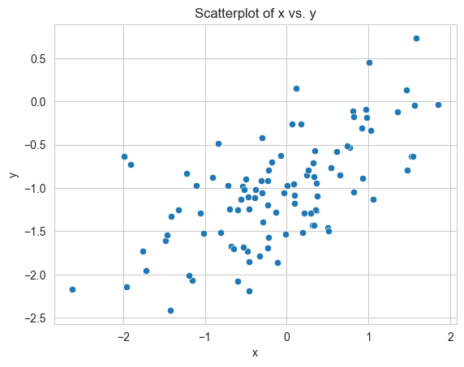

```python
# BEGIN SOLUTION

sns.scatterplot(x=x, y=y)

plt.xlabel('x')
plt.ylabel('y')
plt.title('Scatterplot of x vs. y')

plt.show()

# END SOLUTION
```

The scatter plot suggest that there might exists a positive linear relationship between x and y. The deviation of points from the regression line is due to the random eps values which we added.

### e) Fit a least squares linear model that relates y and `x`. Comment on the model obtained. How do the estimated coefficients (slope and intercept) compare to the true values used to simulate the data?

```python
# BEGIN SOLUTION

df_xe = pd.DataFrame({'x': x})
df_ye = pd.DataFrame({'y': y})

df_xe = sm.add_constant(df_xe)

# Fit the OLS model
model6e = sm.OLS(df_ye, df_xe).fit()

print(model6e.summary())


# END SOLUTION
```

```
                            OLS Regression Results
==============================================================================
Dep. Variable:                      y   R-squared:                       0.404
Model:                            OLS   Adj. R-squared:                  0.398
Method:                 Least Squares   F-statistic:                     66.47
Date:                Thu, 30 Jan 2025   Prob (F-statistic):           1.20e-12
Time:                        22:53:46   Log-Likelihood:                -66.393
No. Observations:                 100   AIC:                             136.8
Df Residuals:                      98   BIC:                             142.0
Df Model:                           1
Covariance Type:            nonrobust
==============================================================================
                 coef    std err          t      P>|t|      [0.025      0.975]
------------------------------------------------------------------------------
const         -0.9963      0.048    -20.847      0.000      -1.091      -0.901
x              0.4284      0.053      8.153      0.000       0.324       0.533
==============================================================================
Omnibus:                        1.950   Durbin-Watson:                   2.194
Prob(Omnibus):                  0.377   Jarque-Bera (JB):                1.909
Skew:                           0.327   Prob(JB):                        0.385
Kurtosis:                       2.829   Cond. No.                         1.16
==============================================================================

Notes:
[1] Standard Errors assume that the covariance matrix of the errors is correctly specified.
```

The estimated coefficients (β^o and β^1) are close to the true values (β₀ = -1, β₁ = 0.5), confirming that the model effectively captures the relationship between x and y. Both coefficients are statistically significant, indicating their meaningful impact on predicting y.

The $R^2$ value of 0.404 suggests that the model explains 40.4% of the variation in y, indicating a moderate fit. The relatively lower $R^2$ may be attributed to the high variance in the error term (eps), which adds randomness and reduces the model’s explanatory power.

### f) Display the least squares line on the scatterplot obtained in (d). Draw the estimated regression line on the plot, in a different color. Feel free to use any framework such as ggplot or matplotlib, seaborn etc

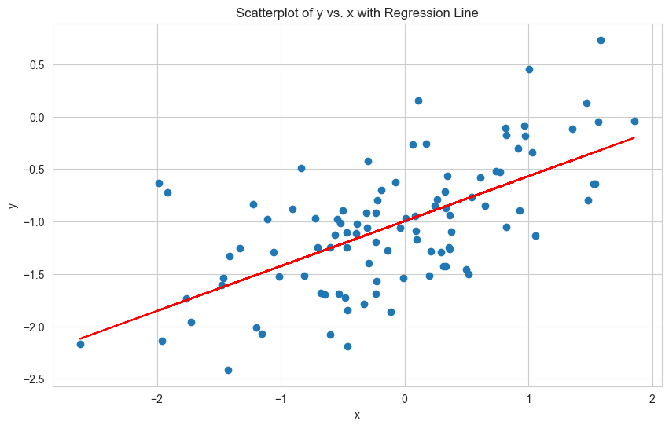

```python
# BEGIN SOLUTION

intercept = model6e.params.iloc[0]
slope = model6e.params.iloc[1]

# Create the scatterplot
plt.figure(figsize=(10, 6))
plt.scatter(x, y, label='Data Points')

# Plot the regression line
plt.plot(x, slope * x + intercept, color='red', label='Regression Line')

plt.xlabel('x')
plt.ylabel('y')
plt.title('Scatterplot of y vs. x with Regression Line')
plt.grid(True)
plt.show()

# END SOLUTION
```

The fitted regression line appears to divide the points into two halves, which indicates that the model provides a balanced fit to the data but the magnitude of the deviation of points are higher.

### g) Now fit a polynomial regression model that predicts $y$ using $x$ and $x^2$. Is there evidence that the quadratic term improves the model fit? Explain your answer.

```python
# BEGIN SOLUTION

x_squared = x**2

# Add constant, x, and x squared to the design matrix
X_6g = sm.add_constant(np.column_stack((x, x_squared)))

# Fit the polynomial regression model
model6g = sm.OLS(y, X_6g).fit()

# Print the model summary
print(model6g.summary())

# END SOLUTION
```

```
                            OLS Regression Results
==============================================================================
Dep. Variable:                      y   R-squared:                       0.432
Model:                            OLS   Adj. R-squared:                  0.420
Method:                 Least Squares   F-statistic:                     36.87
Date:                Thu, 30 Jan 2025   Prob (F-statistic):           1.23e-12
Time:                        22:55:18   Log-Likelihood:                -64.010
No. Observations:                 100   AIC:                             134.0
Df Residuals:                      97   BIC:                             141.8
Df Model:                           2
Covariance Type:            nonrobust
==============================================================================
                 coef    std err          t      P>|t|      [0.025      0.975]
------------------------------------------------------------------------------
const         -1.0691      0.058    -18.558      0.000      -1.183      -0.955
x1             0.4621      0.054      8.582      0.000       0.355       0.569
x2             0.0922      0.042      2.176      0.032       0.008       0.176
==============================================================================
Omnibus:                        2.075   Durbin-Watson:                   2.233
Prob(Omnibus):                  0.354   Jarque-Bera (JB):                1.910
Skew:                           0.239   Prob(JB):                        0.385
Kurtosis:                       2.521   Cond. No.                         2.27
==============================================================================

Notes:
[1] Standard Errors assume that the covariance matrix of the errors is correctly specified.
```

### h) Repeat (a)–(f) after modifying the data generation process in such a way that there is less noise in the data. The model analyzed in this section,, should remain the same. You can do this by decreasing the variance of the normal distribution used to generate the error term ϵ in (b). Describe your results.

```python
# BEGIN SOLUTION

xh = np.random.normal(loc=0, scale=1, size=100)
epsh = np.random.normal(loc=0, scale=0.1, size=100)

yh = (-1) + 0.5 * xh + epsh

df_xh = pd.DataFrame({'x': xh})
df_yh = pd.DataFrame({'y': yh})

df_xh = sm.add_constant(df_xh)

# Fit the OLS model for question 6h
model6h = sm.OLS(df_yh, df_xh).fit()

print(model6h.summary())


# END SOLUTION
```

```
                            OLS Regression Results
==============================================================================
Dep. Variable:                      y   R-squared:                       0.974
Model:                            OLS   Adj. R-squared:                  0.974
Method:                 Least Squares   F-statistic:                     3685.
Date:                Thu, 30 Jan 2025   Prob (F-statistic):           1.47e-79
Time:                        22:58:12   Log-Likelihood:                 101.19
No. Observations:                 100   AIC:                            -198.4
Df Residuals:                      98   BIC:                            -193.2
Df Model:                           1
Covariance Type:            nonrobust
==============================================================================
                 coef    std err          t      P>|t|      [0.025      0.975]
------------------------------------------------------------------------------
const         -0.9893      0.009   -111.133      0.000      -1.007      -0.972
x              0.5000      0.008     60.702      0.000       0.484       0.516
==============================================================================
Omnibus:                        0.784   Durbin-Watson:                   1.854
Prob(Omnibus):                  0.676   Jarque-Bera (JB):                0.876
Skew:                           0.197   Prob(JB):                        0.645
Kurtosis:                       2.765   Cond. No.                         1.10
==============================================================================

Notes:
[1] Standard Errors assume that the covariance matrix of the errors is correctly specified.
```

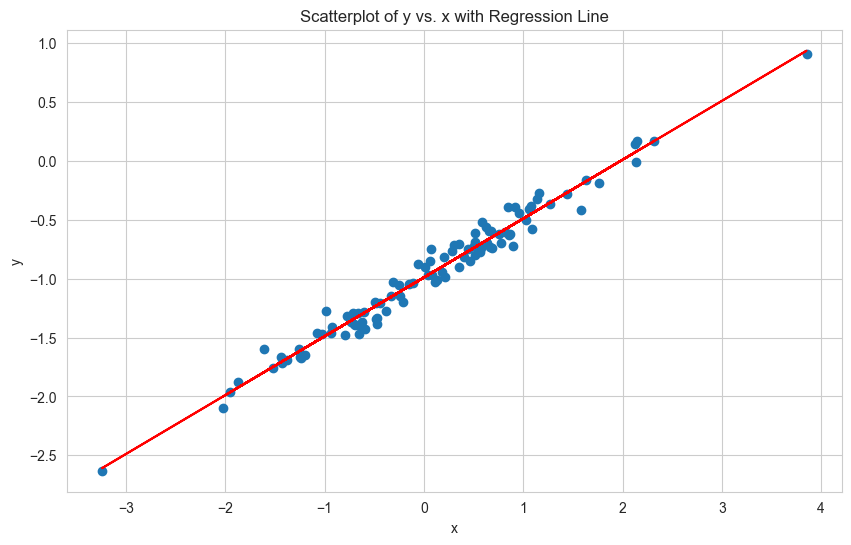

```python
intercept = model6h.params.iloc[0]
slope = model6h.params.iloc[1]

# Create the scatterplot
plt.figure(figsize=(10, 6))
plt.scatter(x=xh, y=yh, label='Data Points')

# Plot the regression line
plt.plot(xh, slope * xh + intercept, label='Regression Line', color='red')

plt.xlabel('x')
plt.ylabel('y')
plt.title('Scatterplot of y vs. x with Regression Line')
plt.grid(True)
plt.show()
```

R-square $\approx$ 0.974 shows that this model fits the data much better. We can also observe in the graph that all the points are scattered quite close to the regression line.

### i) Repeat (a)–(f) after modifying the data generation process in such a way that there is more noise in the data. The model analyzed in this section ($Y = -1 + 0.5X + ϵ$) should remain the same. You can do this by increasing the variance of the normal distribution used to generate the error term $ϵ$ in (b). Describe your results.

```python
# BEGIN SOLUTION

xi = np.random.normal(loc=0, scale=1, size=100)
epsi = np.random.normal(loc=0, scale=0.75, size=100)

yi = (-1) + 0.5 * xi + epsi

df_xi = pd.DataFrame({'x': xi})
df_yi = pd.DataFrame({'y': yi})

df_xi = sm.add_constant(df_xi)

# Fit the OLS model for question 6e
model6i = sm.OLS(df_yi, df_xi).fit()

print(model6i.summary())

# END SOLUTION
```

```
                            OLS Regression Results
==============================================================================
Dep. Variable:                      y   R-squared:                       0.317
Model:                            OLS   Adj. R-squared:                  0.310
Method:                 Least Squares   F-statistic:                     45.52
Date:                Thu, 30 Jan 2025   Prob (F-statistic):           1.06e-09
Time:                        22:59:13   Log-Likelihood:                -104.27
No. Observations:                 100   AIC:                             212.5
Df Residuals:                      98   BIC:                             217.8
Df Model:                           1
Covariance Type:            nonrobust
==============================================================================
                 coef    std err          t      P>|t|      [0.025      0.975]
------------------------------------------------------------------------------
const         -1.0897      0.069    -15.693      0.000      -1.228      -0.952
x              0.4420      0.066      6.747      0.000       0.312       0.572
==============================================================================
Omnibus:                        0.436   Durbin-Watson:                   2.120
Prob(Omnibus):                  0.804   Jarque-Bera (JB):                0.126
Skew:                          -0.045   Prob(JB):                        0.939
Kurtosis:                       3.149   Cond. No.                         1.08
==============================================================================

Notes:
[1] Standard Errors assume that the covariance matrix of the errors is correctly specified.
```

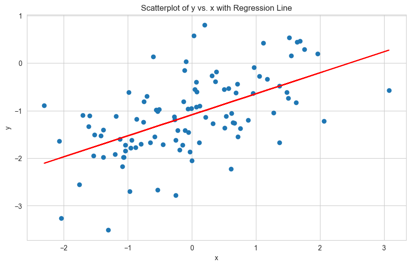

```python
intercept = model6i.params.iloc[0]
slope = model6i.params.iloc[1]

# Create the scatterplot
plt.figure(figsize=(10, 6))
plt.scatter(x=xi, y=yi, label='Data Points')

# Plot the regression line
plt.plot(xi, slope * xi + intercept, color='red', label='Regression Line')

plt.xlabel('x')
plt.ylabel('y')
plt.title('Scatterplot of y vs. x with Regression Line')
plt.grid(True)
plt.show()
```

A low $R^2$ $ \approx $ 0.317 and the above graph shows that this model is not a good fit.

### j) What are the confidence intervals for $β_0$ and $β_1$ based on the original data set, the noisier data set, and the less noisy data set? Comment on your results.

```python
# BEGIN SOLUTION

# Extract confidence intervals for original data
conf_int = model6e.conf_int()

# Extract confidence intervals for less noisy data
conf_int_with_less_noisy = model6h.conf_int()

# Extract confidence intervals for noisier data
conf_int_with_more_noise = model6i.conf_int()

print("Confidence Intervals Original data:")
print(conf_int)

print("\nConfidence Intervals with less noise:")
print(conf_int_with_less_noisy)

print("\nConfidence Intervals with high noise:")
print(conf_int_with_more_noise)

# END SOLUTION
```

```
Confidence Intervals Original data:
              0         1
const -1.091125 -0.901447
x      0.324103  0.532640

Confidence Intervals with less noise:
              0         1
const -1.006980 -0.971649
x      0.483634  0.516324

Confidence Intervals with high noise:
              0         1
const -1.227524 -0.951928
x      0.312009  0.572035
```

When there is more noise in the data, the model becomes less certain about the true values of the coefficients, leading to wider confidence intervals. This means the estimates are less precise.

On the other hand, when there is less noise, the model can predict more accurately, resulting in narrower confidence intervals and more precise estimates of the coefficients.

## Question 7

This question focuses on the collinearity problem

## (a) Perform the following commands in `Python`

```python
import numpy as np

np.random.seed(1)

x1 = np.random.uniform(size=100)

x2 = 0.5 * x1 + np.random.normal(size=100) / 10

y = 2 + 2 * x1 + 0.3 * x2 + np.random.normal(size=100)
```

The last line corresponds to creating a linear model in which $y$ is a function of $x_1$ and $x_2$. Write out the form of the linear model. What are the regression coefficients?

$Y = B_0 + B_1X_1 + B_2X_2 + ϵ$

Where:

$B_o$ = 2 as Intercept  
$B_1$ = 2 as Coefficient of x1  
$B_2$ = 0.3 as Coefficient of x2  
$x_1$ = Predictor/Independent variable 1  
$x_2$ = Predictor/Independent variable 2  
$y$ = Dependent/Response variable  
$ϵ$ = Normally distributed 100 random noise.

Thus the model is:

$y = 2 + 2x_1 + 0.3x_2 + ϵ$

## (b) What is the correlation between $x_1$ and $x_2$? Create a scatterplot displaying the relationship between the variables.

link to correlation function: https://numpy.org/doc/stable/reference/generated/numpy.corrcoef.html

```python
# BEGIN SOLUTION
corr = np.corrcoef(x1, x2)
corr
# END SOLUTION
```

```
array([[1.        , 0.83905962],
       [0.83905962, 1.        ]])
```

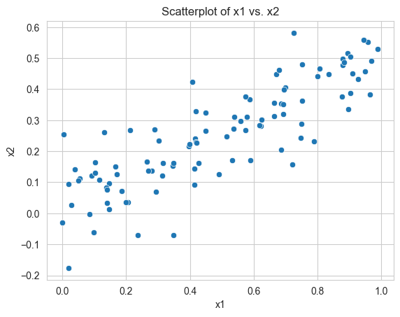

```python
sns.scatterplot(x=x1, y=x2)

plt.xlabel('x1')
plt.ylabel('x2')
plt.title('Scatterplot of x1 vs. x2')

plt.show()
```

Looking at the plot and Correlation Matrix we can observe that $X_1$ and $X_2$ are highly positively correlated with a correlation value $\approx$ $0.839$.

## (c) Using this data, fit a least squares regression to predict $y$ using $x_1$ and $x_2$. Describe the results obtained. What are $β_0$, $β_1$, and $β_2$? How do these relate to the true $β_0$, $β_1$, and $β_2$? Can you reject the null hypothesis $H_0$: $β_1$ = 0? How about the null hypothesis $H_0$: $β_2$ = 0?

```python
# BEGIN SOLUTION

df_x1 = pd.DataFrame({'x1': x1})
df_x2 = pd.DataFrame({'x2': x2})
df_y = pd.DataFrame({'y': y})

df_x_q7c = pd.concat([df_x1, df_x2], axis=1)
df_x_q7c = sm.add_constant(df_x_q7c)

# Fit the regression model
model7c = sm.OLS(df_y, df_x_q7c).fit()

# Print the model summary
print(model7c.summary())

# END SOLUTION
```

```
                            OLS Regression Results
==============================================================================
Dep. Variable:                      y   R-squared:                       0.261
Model:                            OLS   Adj. R-squared:                  0.245
Method:                 Least Squares   F-statistic:                     17.09
Date:                Thu, 30 Jan 2025   Prob (F-statistic):           4.40e-07
Time:                        23:01:28   Log-Likelihood:                -142.34
No. Observations:                 100   AIC:                             290.7
Df Residuals:                      97   BIC:                             298.5
Df Model:                           2
Covariance Type:            nonrobust
==============================================================================
                 coef    std err          t      P>|t|      [0.025      0.975]
------------------------------------------------------------------------------
const          2.1893      0.199     11.021      0.000       1.795       2.584
x1             0.7046      0.637      1.107      0.271      -0.559       1.968
x2             2.5024      1.140      2.194      0.031       0.239       4.766
==============================================================================
Omnibus:                        0.607   Durbin-Watson:                   2.111
Prob(Omnibus):                  0.738   Jarque-Bera (JB):                0.577
Skew:                          -0.179   Prob(JB):                        0.749
Kurtosis:                       2.900   Cond. No.                         14.3
==============================================================================

Notes:
[1] Standard Errors assume that the covariance matrix of the errors is correctly specified.
```

# Model Analysis and Multicollinearity Impact

The estimated coefficients are $B_0$ $\approx$ 2.18, $B_1$ $\approx$ 0.70, and $B_2$ $\approx$ 2.50. While the intercept is close to the true value 2, the coefficients for $X_1$ and $X_2$ differ significantly from their expected values.

- The high p-value for $B_1$ suggests that y does not significantly depend on $x_1$.
- The low p-value for $B_2$ confirms that y depends on $x_2$.
- Although $x_1$ and $x_2$ are correlated, their expected impact on y is not well captured in the model.

P value for $B_2$ is less than 0.05 and hence H0 for $B_2$ can be rejected i.e. Y has a dependency on x2 as per the model. One more observation, even though $x_1$ and $x_2$ are corelated and should have had impact on the response (y) still the same is not visible in model summary, this suggests that the model is not performing properly due to multicolinearity.

## (d) Now fit a least squares regression to predict $y$ using only $x_1$. Comment on your results. Can you reject the null hypothesis $H_0$: $β_1$ = 0?

```python
# BEGIN SOLUTION

df_x_q7d = sm.add_constant(df_x1)

# Fit the regression model
model7d = sm.OLS(df_y, df_x_q7d).fit()

# Print the model summary
print(model7d.summary())

# END SOLUTION
```

```
                            OLS Regression Results
==============================================================================
Dep. Variable:                      y   R-squared:                       0.224
Model:                            OLS   Adj. R-squared:                  0.216
Method:                 Least Squares   F-statistic:                     28.26
Date:                Thu, 30 Jan 2025   Prob (F-statistic):           6.68e-07
Time:                        23:02:42   Log-Likelihood:                -144.76
No. Observations:                 100   AIC:                             293.5
Df Residuals:                      98   BIC:                             298.7
Df Model:                           1
Covariance Type:            nonrobust
==============================================================================
                 coef    std err          t      P>|t|      [0.025      0.975]
------------------------------------------------------------------------------
const          2.2486      0.201     11.209      0.000       1.850       2.647
x1             1.8770      0.353      5.316      0.000       1.176       2.578
==============================================================================
Omnibus:                        0.292   Durbin-Watson:                   2.123
Prob(Omnibus):                  0.864   Jarque-Bera (JB):                0.468
Skew:                          -0.003   Prob(JB):                        0.791
Kurtosis:                       2.665   Cond. No.                         4.26
==============================================================================

Notes:
[1] Standard Errors assume that the covariance matrix of the errors is correctly specified.
```

The estimated coefficients $B_0$ $\approx$ 2.24 and $B_1$ $\approx$ 1.87 are close to their true values, showing a good fit. Since the p-value is less than 0.05, we can reject the null hypothesis (H0) for $B_1$. This suggests that Y strongly depends on $X_1$ in the model.

## (e) Now fit a least squares regression to predict $y$ using only $x_2$. Comment on your results. Can you reject the null hypothesis $H_0$: $β_1$ = 0?

```python
# BEGIN SOLUTION

df_x_q7e = sm.add_constant(df_x2)

# Fit the polynomial regression model
model7e = sm.OLS(df_y, df_x_q7e).fit()

# Print the model summary
print(model7e.summary())

# END SOLUTION
```

```
                            OLS Regression Results
==============================================================================
Dep. Variable:                      y   R-squared:                       0.251
Model:                            OLS   Adj. R-squared:                  0.244
Method:                 Least Squares   F-statistic:                     32.87
Date:                Thu, 30 Jan 2025   Prob (F-statistic):           1.09e-07
Time:                        23:03:03   Log-Likelihood:                -142.97
No. Observations:                 100   AIC:                             289.9
Df Residuals:                      98   BIC:                             295.1
Df Model:                           1
Covariance Type:            nonrobust
==============================================================================
                 coef    std err          t      P>|t|      [0.025      0.975]
------------------------------------------------------------------------------
const          2.2655      0.187     12.145      0.000       1.895       2.636
x2             3.5613      0.621      5.733      0.000       2.329       4.794
==============================================================================
Omnibus:                        0.857   Durbin-Watson:                   2.117
Prob(Omnibus):                  0.651   Jarque-Bera (JB):                0.746
Skew:                          -0.210   Prob(JB):                        0.689
Kurtosis:                       2.946   Cond. No.                         6.48
==============================================================================

Notes:
[1] Standard Errors assume that the covariance matrix of the errors is correctly specified.
```

The estimated coefficients $B_0$ $\approx$ 2.26 and $B_2$ $\approx$ 3.56 show that $B_0$ is close to the true intercept, but $B_2$ is quite different from its expected value. Since the p-value is less than 0.05, we can reject $H_0$ for $B_2$. This means $Y$ depends on $X_2$, but with a different coefficient than expected.

## (f) Do the results obtained in (c)–(e) contradict each other? Explain your answer.

Yes, the results contradict each other because $X_1$ and $X_2$ are highly correlated, leading to collinearity. This makes it difficult to determine the independent effect of each predictor on $Y$. Collinearity increases the standard errors of $B_1$ and $B_2$, reducing the accuracy of their estimates. As a result, we fail to reject $H_0$ for $X_1$, and the true importance of $X_1$ and $X_2$ is masked.

## (g) Now suppose we obtain one additional observation, which was unfortunately mismeasured. Re-fit the linear models from (c) to (e) using this new data. What effect does this new observation have on each of the models? In each model, is this observation an outlier? A high-leverage point? Both? Explain your answers.

```python
# BEGIN SOLUTION

# Generate new random observations for x1 and x2 and y
x1_new = np.random.uniform(size=1)
x2_new = 0.5 * x1_new + np.random.normal(size=1) / 10
y_new = 2 + 2 * x1_new + 0.3 * x2_new + np.random.normal(size=1)

#print(x1_new, x2_new, y_new)

# Update dataframes correctly and reset indices
df_x1_q7g = pd.concat([df_x1, pd.DataFrame({'x1': x1_new})], ignore_index=True)
df_x2_q7g = pd.concat([df_x2, pd.DataFrame({'x2': x2_new})], ignore_index=True)
df_y_q7g = pd.concat([df_y, pd.DataFrame({'y': y_new})], ignore_index=True)

#print(len(df_x1_q7g), len(df_x2_q7g), len(df_y_q7g))

# Combine x1 and x2 into one dataframe and reset index to match df_y
df_x_q7g = pd.concat([df_x1_q7g, df_x2_q7g], axis=1)

# Fit regression model with both x predictors
model7gx = sm.OLS(df_y_q7g, sm.add_constant(df_x_q7g)).fit()

# Fit regression model with only x1
model7gx1 = sm.OLS(df_y_q7g, sm.add_constant(df_x1_q7g)).fit()

# Fit regression model with only x1
model7gx2 = sm.OLS(df_y_q7g, sm.add_constant(df_x2_q7g)).fit()

# END SOLUTION
```

```
Model Summary for Both X1 and X2
                            OLS Regression Results
==============================================================================
Dep. Variable:                      y   R-squared:                       0.261
Model:                            OLS   Adj. R-squared:                  0.246
Method:                 Least Squares   F-statistic:                     17.30
Date:                Thu, 30 Jan 2025   Prob (F-statistic):           3.68e-07
Time:                        23:03:43   Log-Likelihood:                -144.58
No. Observations:                 101   AIC:                             295.2
Df Residuals:                      98   BIC:                             303.0
Df Model:                           2
Covariance Type:            nonrobust
==============================================================================
                 coef    std err          t      P>|t|      [0.025      0.975]
------------------------------------------------------------------------------
const          2.1553      0.199     10.825      0.000       1.760       2.550
x1             0.8020      0.639      1.255      0.212      -0.466       2.070
x2             2.3848      1.147      2.079      0.040       0.108       4.661
==============================================================================
Omnibus:                        0.536   Durbin-Watson:                   2.116
Prob(Omnibus):                  0.765   Jarque-Bera (JB):                0.593
Skew:                          -0.168   Prob(JB):                        0.743
Kurtosis:                       2.831   Cond. No.                         14.3
==============================================================================

Notes:
[1] Standard Errors assume that the covariance matrix of the errors is correctly specified.
```

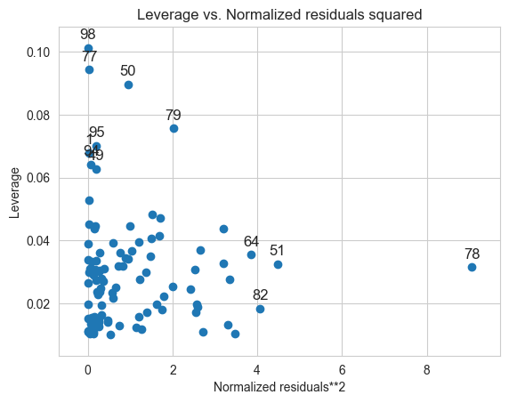

```python
print("Model Summary for Both X1 and X2")
print(model7gx.summary())

sm.graphics.plot_leverage_resid2(model7gx)
plt.show()
```

```
Model Summary for X1
                            OLS Regression Results
==============================================================================
Dep. Variable:                      y   R-squared:                       0.228
Model:                            OLS   Adj. R-squared:                  0.221
Method:                 Least Squares   F-statistic:                     29.29
Date:                Thu, 30 Jan 2025   Prob (F-statistic):           4.35e-07
Time:                        23:03:53   Log-Likelihood:                -146.76
No. Observations:                 101   AIC:                             297.5
Df Residuals:                      99   BIC:                             302.8
Df Model:                           1
Covariance Type:            nonrobust
==============================================================================
                 coef    std err          t      P>|t|      [0.025      0.975]
------------------------------------------------------------------------------
const          2.2149      0.200     11.058      0.000       1.817       2.612
x1             1.9157      0.354      5.412      0.000       1.213       2.618
==============================================================================
Omnibus:                        0.469   Durbin-Watson:                   2.126
Prob(Omnibus):                  0.791   Jarque-Bera (JB):                0.607
Skew:                           0.003   Prob(JB):                        0.738
Kurtosis:                       2.620   Cond. No.                         4.26
==============================================================================

Notes:
[1] Standard Errors assume that the covariance matrix of the errors is correctly specified.
```

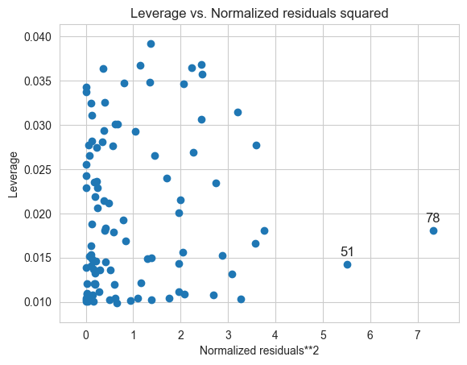

```python
print("Model Summary for X1")
print(model7gx1.summary())

sm.graphics.plot_leverage_resid2(model7gx1)
plt.show()
```

```
Model Summary for X2
                            OLS Regression Results
==============================================================================
Dep. Variable:                      y   R-squared:                       0.249
Model:                            OLS   Adj. R-squared:                  0.241
Method:                 Least Squares   F-statistic:                     32.83
Date:                Thu, 30 Jan 2025   Prob (F-statistic):           1.09e-07
Time:                        23:04:03   Log-Likelihood:                -145.39
No. Observations:                 101   AIC:                             294.8
Df Residuals:                      99   BIC:                             300.0
Df Model:                           1
Covariance Type:            nonrobust
==============================================================================
                 coef    std err          t      P>|t|      [0.025      0.975]
------------------------------------------------------------------------------
const          2.2403      0.188     11.931      0.000       1.868       2.613
x2             3.5921      0.627      5.730      0.000       2.348       4.836
==============================================================================
Omnibus:                        0.799   Durbin-Watson:                   2.123
Prob(Omnibus):                  0.671   Jarque-Bera (JB):                0.777
Skew:                          -0.206   Prob(JB):                        0.678
Kurtosis:                       2.880   Cond. No.                         6.51
==============================================================================

Notes:
[1] Standard Errors assume that the covariance matrix of the errors is correctly specified.
```

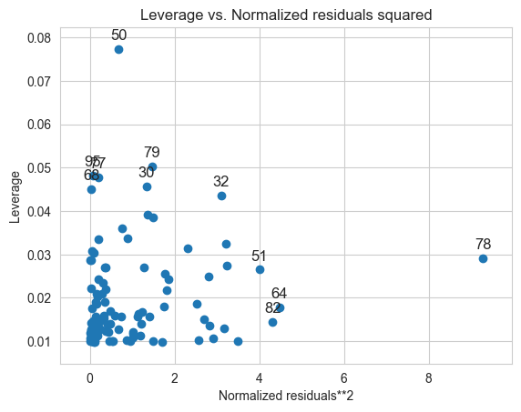

```python
print("Model Summary for X2")
print(model7gx2.summary())

sm.graphics.plot_leverage_resid2(model7gx2)
plt.show()
```

## Question 8

It is claimed that in the case of simple linear regression of $Y$ onto $X$, the $R^2$ statistic is equal to the square of the correlation between $X$ and $Y$. Generate some synthetic data and show that this is the case.

link to correlation function: https://numpy.org/doc/stable/reference/generated/numpy.corrcoef.html

```python
# BEGIN SOLUTION

np.random.seed(4)
x = np.random.uniform(size=100)
y = 2 + 2 * x + np.random.normal(size=100)

corr = np.corrcoef(x, y)[0,1]
X = sm.add_constant(x)
model = sm.OLS(y, X).fit()

print(f"Correlation Coefficient is: {corr}")
print(f"Squared Correlation is: {corr ** 2}")
print(f"R-squared from Regression is: {model.rsquared}")
print(f"Square of correlation == R-squared?: {np.equal(corr ** 2, model.rsquared)}")

# END SOLUTION
```

```
Correlation Coefficient is: 0.47946756684065156
Squared Correlation is: 0.22988914765209467
R-squared from Regression is: 0.22988914765209467
Square of correlation == R-squared?: True
```